# Importing the data into R and Signac+Seurat, initial QC and clustering

## Add genome annotation to Seurat object

Next, we add annotation to our `Seurat` object. This will allow downstream functions to pull the gene annotation information directly from the object.

First, let’s retrieve all available genome annotations:

```r
# downloads database to the cache
annHub <- AnnotationHub(ask = FALSE)
## Query for all available EnsDb mouse databases
annVersions = query(annHub, pattern = c("Mmusculus","EnsDb"))
```

Now, we can choose one of them and select them as annotation for our `Seurat` object.

```r
# Now we chose an appropriate annotation version that matches our genome:
# Here, mm10 corresponds to GRCm38
which(annVersions$genome == "GRCm38")
```

```
 [1]  1  2  3  4  5  6  7  8  9 10 11 12 13 14 15 16
```

```r
# Pick the newest, here with index 16
annVersionName = names(annVersions)[16]

# Retrieving ENSEMBL 102 release with ID AH89211  for mm10
adb.use <-  annVersions[[annVersionName]]
adb.use
```

```
EnsDb for Ensembl:
|Backend: SQLite
|Db type: EnsDb
|Type of Gene ID: Ensembl Gene ID
|Supporting package: ensembldb
|Db created by: ensembldb package from Bioconductor
|script_version: 0.3.6
|Creation time: Sun Dec 20 12:15:16 2020
|ensembl_version: 102
|ensembl_host: localhost
|Organism: Mus musculus
|taxonomy_id: 10090
|genome_build: GRCm38
|DBSCHEMAVERSION: 2.1
| No. of genes: 56305.
| No. of transcripts: 144778.
|Protein data available.
```

```r
# use only standard chromosomes for annotation
annotations <- suppressMessages(suppressWarnings(
    GetGRangesFromEnsDb(adb.use, standard.chromosomes = TRUE)))

# change to UCSC style since the data was mapped to mm10
seqlevelsStyle(annotations) <- 'UCSC'
Annotation(seu[["ATAC"]]) <- annotations
```

## Initial data filtering: Filtering peaks

First, we will filter out some peaks that are located outside of the regular chromosomes. usually, this only affects a very small number of peaks, but it is nevertheless a good idea to do so! This also teaches you how to filter a `Seurat` object!

```r
# Number of rows (here, this corresponds to peaks) before any filtering
nrow(seu)
```

```
[1] 20000
```

```r
genome(seu@assays$ATAC@ranges) <- "mm10"

# Get a list of all main chromosomes from the annotation
main.chroms <- levels(seqnames(annotations))

# Determine for each peak whether it is located on a main chromosome (TRUE) or not (FALSE)
keep.peaks <- which(as.character(seqnames(granges(seu[["ATAC"]]))) %in% main.chroms)

# Filter the object and discard peaks
seu[["ATAC"]] <- subset(seu[["ATAC"]], features = rownames(seu[["ATAC"]])[keep.peaks])

seu
```

```
An object of class Seurat
20000 features across 1000 samples within 1 assay
Active assay: ATAC (20000 features, 0 variable features)
 2 layers present: counts, data
```

How many peaks we have now, can you compare this to the number of peaks before the filtering?

## Detection and handling of doublets/multiplets

Doublet detection is a crucial step in the analysis of single-cell data. Doublets are technical artifacts that occur when two or more cells are mistakenly encapsulated into one reaction volume, leading to the generation of artificial cells that can confound downstream analyses. Identifying and removing doublets is important to ensure accurate interpretation of scRNA-seq data and to avoid spurious biological conclusions.

`CellRanger ATAC` currently does not have a method for computationally classifying whether a barcode contains more than one cell in single cell gene expression data from a single species. Thus, we need to use other tools for doublet detection. Multiple tools exist, but most have originally been developed for scRNA-seq data. These methods aim to distinguish real cells from doublets by analyzing gene expression patterns. One such method is DoubletFinder, which predicts doublets based on the proximity of real cells in gene expression space to artificial doublets created by averaging the transcriptional profiles of randomly chosen cell pairs. `DoubletFinder` uses only gene expression data and has been shown to be effective in identifying doublets.

Another method is `scDblFinder`, which has originally also been developed for doublet detection in scRNA-seq data. It uses a cluster-based approach and selects the top most expressed features to reduce the dataset before detecting doublets. However, methods that were built / optimized for scRNA-seq may not perform well for scATAC-seq because scRNA-seq are typically limited to a relatively small set of features that are most informative (typically, a few thousands): genes with a higher expression. In contrast, scATACseq data is considerably more sparse, with most reads being spread across hundreds of thousands of regions. Selecting a subset of genes therefore is not very suitable.

`scDblFinder` specifically developed and implemented doublet detection methods for scATAC-seq, and we here present and use one of them. For the other available methods for scATAC-data, [see the Vignette](https://bioconductor.org/packages/release/bioc/vignettes/scDblFinder/inst/doc/scATAC.html) for more details. Default options will not work well for scATAC-seq, but using the options `aggregateFeatures = TRUE` as well as a (relatively small) value for `nfeatures` supposedly works well for many datasets:

```r
ATAC.sce <- as.SingleCellExperiment(seu, assay = "ATAC")
ATAC.sce <- scDblFinder(ATAC.sce, artificialDoublets = 1, aggregateFeatures = TRUE,
                        nfeatures = 25, processing = "normFeatures")

seu$ATAC_doublets = ATAC.sce$scDblFinder.class
rm(ATAC.sce)
```

How many doublets were found? Is this percentage lower or higher what you initially expected? Discuss with your group!

## Quality checks (QC)

We can now compute some QC metrics for the scATAC-seq experiment. Strict QC of scATAC-seq data is essential to remove the contribution of low-quality cells. We currently suggest the following metrics below to assess data quality. As with scRNA-seq, the expected range of values for these parameters will vary depending on your biological system, cell viability, and other factors.

- **Nucleosome banding pattern**: The histogram of DNA fragment sizes (determined from the paired-end sequencing reads) should exhibit a strong nucleosome banding pattern corresponding to the length of DNA wrapped around a single nucleosome. We calculate this per single cell, and quantify the approximate ratio of mononucleosomal to nucleosome-free fragments (stored as `nucleosome_signal`)
- **Transcriptional start site (TSS) enrichment score**. The [ENCODE project](https://www.encodeproject.org/) has defined an ATAC-seq targeting score based on the ratio of fragments centered at the TSS to fragments in TSS-flanking regions (see https://www.encodeproject.org/data-standards/terms/). Poor ATAC-seq experiments typically will have a low TSS enrichment score. We can compute this metric for each cell with the `TSSEnrichment()` function, and the results are stored in metadata under the column name `TSS.enrichment`.
- **Total number of fragments in peaks**: A measure of cellular sequencing depth / complexity. Cells with very few reads may need to be excluded due to low sequencing depth. Cells with extremely high levels may represent doublets, nuclei clumps, or other artefacts.
- **Fraction of fragments in peaks**: Represents the fraction of all fragments that fall within ATAC-seq peaks. Cells with low values (i.e. <15-20%) often represent low-quality cells or technical artifacts that should be removed. Note that this value can be sensitive to the set of peaks used.
- **Ratio reads in genomic blacklist regions:** The [ENCODE project](https://www.encodeproject.org/) has provided a list of [blacklist regions](https://github.com/Boyle-Lab/Blacklist), representing reads which are often associated with artefactual signal. Cells with a high proportion of reads mapping to these areas (compared to reads mapping to peaks) often represent technical artifacts and should be removed. ENCODE blacklist regions for the most commonly used organisms including mouse are included in the `Signac` package.

Note that the last three metrics can be obtained from the output of `Cell Ranger ATAC` (which is stored in the object metadata), but can also be calculated for non-10x datasets using `Signac`.

The number of unique nuclear fragments (i.e. not mapping to mitochondrial DNA). The signal-to-background ratio. Low signal-to-background ratio is often attributed to dead or dying cells which have de-chromatinzed DNA which allows for random transposition genome-wide. The fragment size distribution. Due to nucleosomal periodicity, we expect to see depletion of fragments that are the length of DNA wrapped around a nucleosome (~147 bp). The first metric, unique nuclear fragments, is straightforward - cells with very few usable fragments will not provide enough data to make useful interpretations and should therefore be excluded.

The second metric, signal-to-background ratio, is calculated as the TSS enrichment score. Traditional bulk ATAC-seq analysis has used this TSS enrichment score as part of a standard workflow for determination of signal-to-background (for example, the ENCODE project). We and others have found the TSS enrichment to be representative across the majority of cell types tested in both bulk ATAC-seq and scATAC-seq. The idea behind the TSS enrichment score metric is that ATAC-seq data is universally enriched at gene TSS regions compared to other genomic regions, due to large protein complexes that bind to promoters. By looking at per-basepair accessibility centered at these TSS regions, we see a local enrichment relative to flanking regions (1900-2000 bp distal in both directions). The ratio between the peak of this enrichment (centered at the TSS) relative to these flanking regions represents the TSS enrichment score.

Traditionally, the per-base-pair accessibility is computed for each bulk ATAC-seq sample and then this profile is used to determine the TSS enrichment score. Performing this operation on a per-cell basis in scATAC-seq is relatively slow and computationally expensive. To accurately approximate the TSS enrichment score per single cell, we count the average accessibility within a 50-bp region centered at each single-base TSS position and divide this by the average accessibility of the TSS flanking positions (+/- 1900 – 2000 bp). This approximation was highly correlated (R > 0.99) with the original method and values were extremely close in magnitude.

The third metric, fragment size distribution, is generally less important but always good to manually inspect. Because of the patterned way that DNA wraps around nucleosomes, we expect to see a nucleosomal periodicity in the distribution of fragment sizes in our data. These hills and valleys appear because fragments must span 0, 1, 2, etc. nucleosomes (Tn5 cannot cut DNA that is tightly wrapped around a nucleosome.

### Compute QC metrics

```r
# compute nucleosome signal score per cell
seu <- NucleosomeSignal(object = seu)

# TSS enrichment (takes a few minutes)
seu <- TSSEnrichment(object = seu, fast = FALSE)

# add blacklist ratio and fraction of reads in peaks
seu$pct_reads_in_peaks <- seu$peak_region_fragments / seu$passed_filters * 100

# Set the fraction of reads per cell located in blacklist regions
seu$blacklist_fraction <- FractionCountsInRegion(object = seu, regions = blacklist_mm10)
```

### Visualize TSS enrichment

We can inspect the TSS enrichment scores by grouping the cells based on the score and plotting the accessibility signal over all TSS sites, here stratified by whether or not the TSS enrichment is above 2 or not.

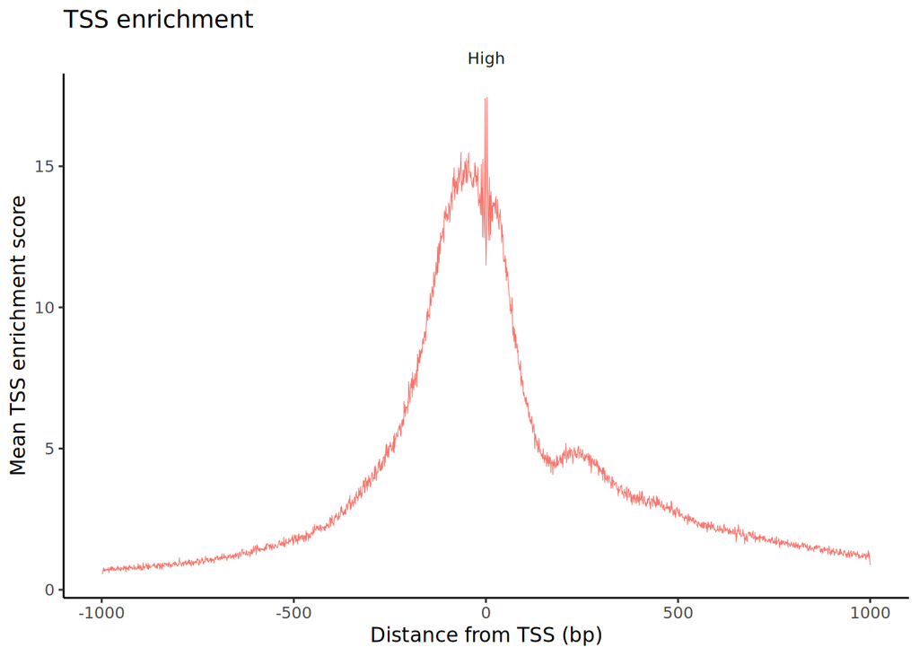

```r
seu$high.tss <- ifelse(seu$TSS.enrichment > 2, 'High', 'Low')
TSSPlot(seu, group.by = 'high.tss') + NoLegend()
```